# STAT 118: Notes J

Maps with `maps` and `sf`

Author

Affiliation

Andrew Villeneuve

University of New Hampshire

### Before we get started, some context:

- `R` is *fantastic* for spatial analysis (not covered in this class… look for classes related to spatial statistics)
- `R` is *great* for interactive data visualization (via `leaflet` or `shiny`… more on this on Thursday)
- `R` is *okay* at spacial data visualization (creating maps).
  - There are many different packages in `R` for creating maps. I’ve found that different packages perform best for different maps. We will talk about a few different ones today.
  - If you have a highly map-centric project, there is nothing wrong with working in ArcGIS or QGIS if you find the mapping tools in R insufficient. There are many recent improvements with new packages (like `sp`, `rgdal` and `rgeos`) which profiles much of the functionality of GIS packages! Exciting! (not very beginner friendly - requires familiarity with GIS concepts)

# Using the `maps` package

Perhaps the simplest approach to drawing maps is to use `geom_polygon()` to draw boundaries for different regions.

The `maps` package contains several built in maps: world (for all countries in the world), france, italy, nz, usa, state (usa state boundaries), and county (usa counties). The maps package isn’t particularly accurate or up-to-date, but it’s built into R so it’s an easy place to start.

To reference each map you use `map_data("mapname")`.

```r
#LOAD PACKAGES
library(tidyverse)
library(maps)
#You may need to install the "devtools" package. This is because jpmap is hosted on Github rather than another server like CRAN.
#If you are prompted to update packages, you can hit <ENTER> to skip - if there is a required update, you will see a message
# install.packages("devtools")
devtools::install_github("UchidaMizuki/jpmap")
library(jpmap)

#LOAD DATA
world_map <- map_data("world")
```

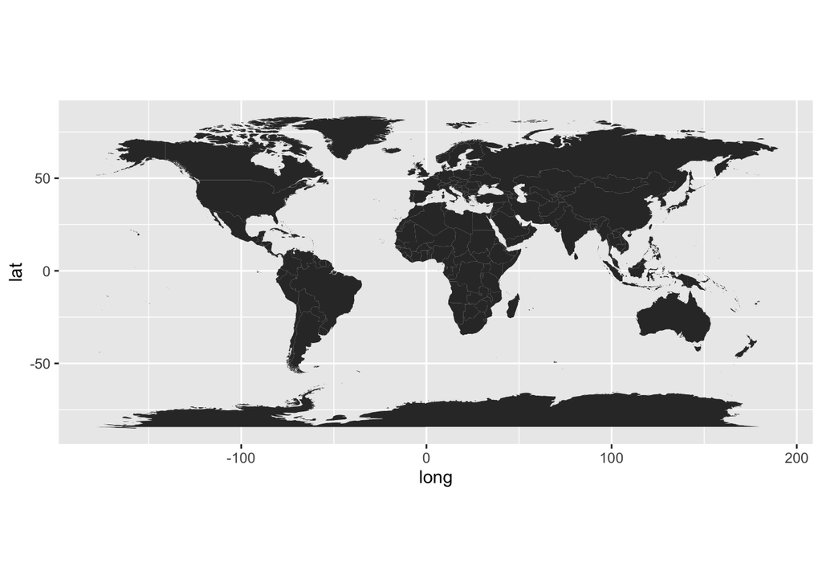

```r
#World Map
ggplot(world_map, aes(long, lat, group=group)) +
  geom_polygon() +
  coord_quickmap()
```

Note:

- `coord_quickmap()` adjusts the axes to ensure that longitude and latitude are rendered on the same scale. It is very important that this aspect ratio is maintained or a country may appear super stretched or super squished.
- the `aes(group=group)` option – This is SUPER IMPORTANT, so R knows which things to connect together

## What about subsetting the data?

```r
#Subset to get Japan
japan <- map_data("world", region ="Japan")

#Subset to get USA
```

## What if aspect ratio is not maintained?

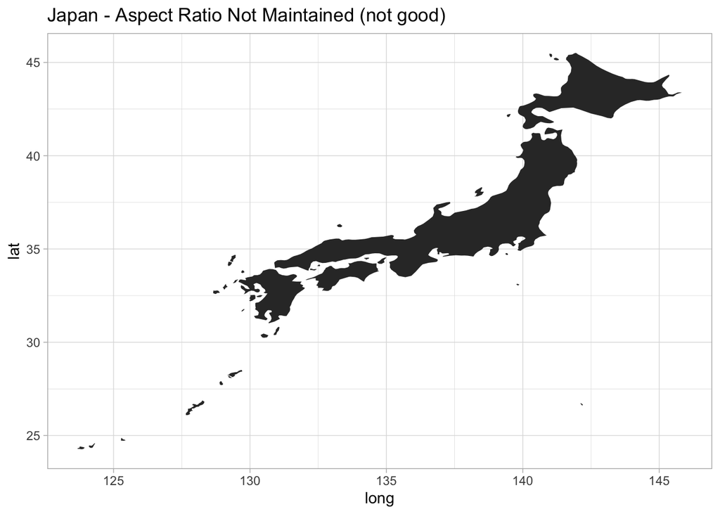

```r
# ASPECT RATIO NOT MAINTAINED.
ggplot(japan, aes(long, lat)) +
  geom_polygon(aes(group=group)) +
  theme_light() +
  ggtitle("Japan - Aspect Ratio Not Maintained (not good)")
```

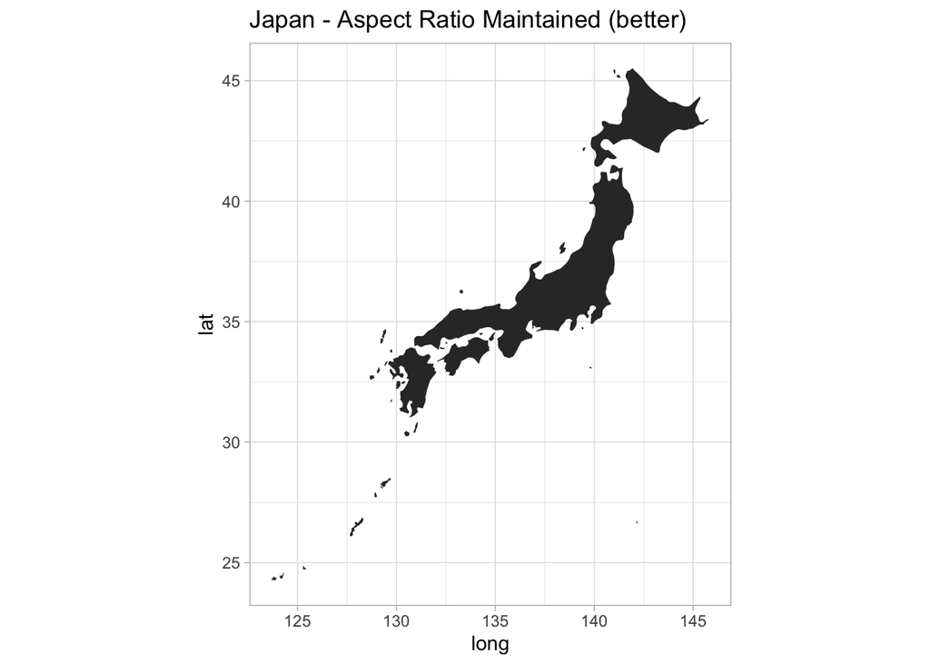

```r
# ASPECT RATIO MAINTAINED
ggplot(japan, aes(long, lat)) +
  geom_polygon(aes(group=group)) +
  coord_quickmap()  +
  theme_light() +
  ggtitle("Japan - Aspect Ratio Maintained (better)")
```

## Japan with Prefectures

```r
#Plot of Japan
```

## How to customize colors?

You can use either numeric codes, or the name of a color, when you specify the palette of your map.

```r
#you can use numeric or character names https://r-charts.com/colors/
```

# Using the `sf` package

There are a few limitations to the approach outlined above, not least of which is the fact that the simple “longitude-latitude” data format is not typically used in real world mapping. Vector data for maps are typically encoded using the “simple features” standard produced by the Open Geospatial Consortium. The `sf` package developed by Edzer Pebesma provides an excellent toolset for working with such data, and the `geom_sf()` and `coord_sf()` functions in ggplot2 are designed to work together with the `sf` package.

```r
#LOAD PACKAGES
#install.packages("sf") - note some students are getting a pop-up when they install the sf package for the first time. Select the "no" option when it pops up in your console.
library(sf)
#some students are needing into install the rgeos package seperately as well
#library(rgeos)

#load japan prefecture map from the jpmap package
prefecture<-jpmap::prefecture

#we need to do a little cleanup on prefecture names - make them all lower case
prefecture$pref_name<-tolower(prefecture$pref_name)

#and now make them all ASCII (non-accented) characters
prefecture$pref_name<-iconv(prefecture$pref_name, from = 'UTF-8', to = 'ASCII//TRANSLIT')
```

For our second example, we will be working with a dataset of Japanese census data tfrom the `choroplethr` package.

```r
#install.packages("choroplethr")
library(choroplethr)
#load the japan census data from the choroplethr package
data(df_japan_census)

#Let's take a peak at the census data
str(df_japan_census)
```

```
'data.frame':   47 obs. of  4 variables:
 $ region                      : chr  "aichi" "akita" "aomori" "chiba" ...
 $ pop_2010                    : num  7411000 1086000 1373000 6216000 1431000 ...
 $ percent_pop_change_2005_2010: num  2.2 -5.2 -4.4 2.6 -2.5 -1.9 0.4 -3 -1.3 -0.8 ...
 $ pop_density_km2_2010        : num  1434.8 93.3 142.4 1205.5 252.1 ...
```

```r
#rename the prefecture. We need to do this in order to merge with the prefecture sf dataframe
df_japan_census<-df_japan_census%>%
  rename("pref_name"="region")

#Now, we can merge the census data with the prefecture sf map.
merged_prefs<-merge(prefecture,df_japan_census,by="pref_name")
```

Each row represents a prefecture in Japan This data frame contains the following columns:

- `pref_name` Name of each prefecture (without capitalization or accent characters)
- `pref_code` Numeric code that is unique to each prefecture
- `pref_name_ja` Name of each prefecture in Japanese
- `pop_2010` Population of each prefecture in 2010
- `pop_density_km2_2010` Population density of each prefecture in $km^2$.
- `geometry` The mapping information inside a special features. Here, each prefecture is a multipolygon.

### Using RColorBrewer palette

```r
library(RColorBrewer)
#color options https://r-graph-gallery.com/38-rcolorbrewers-palettes.html
```

### Using part of a RColorBrewer palette

### Building your own color palette using `scale_fill_gradientn`

A note about customizing colors:

- you should use a color scheme that is sequential (has order to it), when you are displaying continuous data
- you should use a color scheme that is categorical, when your data is in categories and isn’t ordered you should use a color scheme that is diverging, when want to put emphasis on two extremes and mid-range. For example, you might use a diverging palette from red to blue for political party affiliation in the US.
- pay attention to your map being color blind friendly (`RdYlGr` is the worst…)
- as a general rule, try not to use blue to represent a land mass (let’s reserve that for bodies of water)

# `sf` cheatsheet

[`sf` cheatsheet](https://github.com/rstudio/cheatsheets/blob/a045e18875cde4c9cf9c7f5f8bee71b4c8c2a2b7/sf.pdf)